# Applied Computational Methods for Social Sciences

## Difference

Is the difference statistically significant?

```r
ger2d_east<-subset(ger2d, region=="East")
ger2d_west<-subset(ger2d, region=="West")

test_twosided<-t.test(ger2d_east$diff, ger2d_west$diff,
        alternative = c("two.sided"))
test_twosided
```

```
    Welch Two Sample t-test

data:  ger2d_east$diff and ger2d_west$diff
t = 0.48269, df = 115.94, p-value = 0.6302
alternative hypothesis: true difference in means is not equal to 0
95 percent confidence interval:
 -0.5655884  0.9300957
sample estimates:
mean of x mean of y
 5.817208  5.634954
```

In this case, we do not reject the null hypothesis (H0) because p ≥ 0.05 and conclude that there is no significant difference between the means of the two groups.

## Refining the Analysis

One criticism to our analysis is that we are comparing units that are too different.

For example, it feels strange to compare units like Lörrach or Uckermark.

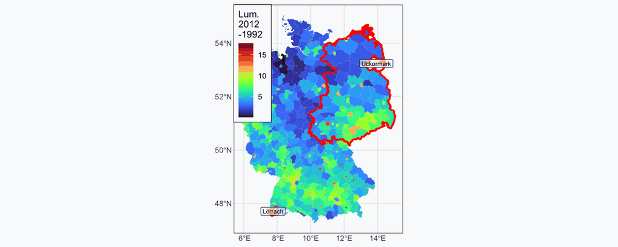

```r
ger_sel<-subset(ger2d, NAME_2=="Lörrach" | NAME_2=="Uckermark")
ggplot() +
  geom_sf(data=ger2d, aes(fill=diff), color="white", linewidth=0.01)+
  scale_fill_viridis(option="turbo",
                      name = "Lum. \n2012\n-1992")+
  geom_sf(data = east_ger_diss4, fill = NA, color = "red", linewidth = 1) +
  theme_bw()+
  theme(axis.title = element_blank(),   # Remove axis titles
        axis.ticks = element_blank(),
        legend.box.background = element_rect(fill = "white",
                                             linewidth=0.5, linetype="solid",
                                             colour = "black"),
        legend.position = c(0, 1),
        legend.justification = c(0, 1))+
  geom_sf(data=ger_sel, color="red", linewidth=1)+
  geom_sf_label(data=ger_sel, aes(label=NAME_2), alpha=0.6, size=2.5)
```

## Refining the Analysis

Counties like Lörrach or Uckermark may be different for other reasons that have nothing to do with exposure to communism.

Thus, it may be more appropriate to examine counties that are close the East-West border

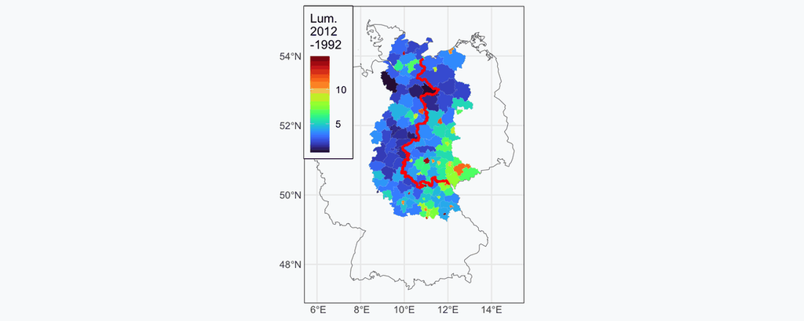

```r
ger_100km$diff<-ger_100km$lights_2012-ger_100km$lights_1992
ggplot()+
  geom_sf(data=ger0, fill=NA)+
  geom_sf(data=ger_100km, aes(fill=diff), color="white", linewidth=0.01)+
  scale_fill_viridis(option="turbo",
                      name = "Lum. \n2012\n-1992")+
  geom_sf(data = line1, color = "red", linewidth = 1) +
  theme_bw()+
  theme(axis.title = element_blank(),   # Remove axis titles
        axis.ticks = element_blank(),
        legend.box.background = element_rect(fill = "white",
                                             linewidth=0.5, linetype="solid",
                                             colour = "black"),
        legend.position = c(0, 1),
        legend.justification = c(0, 1))
```

## Comparison 1992

We can now perform the analysis only based on the 100km sample around the border

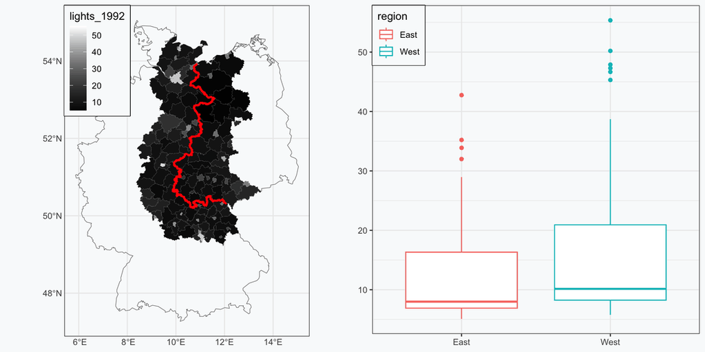

```r
library(gridExtra)

pic1<-ggplot() +
  geom_sf(data=ger0, fill=NA)+
  geom_sf(data=ger_100km, aes(fill=lights_1992), color="white", linewidth=0.01)+
  scale_fill_gradientn(colours=c("black","white"))+
  geom_sf(data = line1, color = "red", linewidth = 1) +
  theme_bw()+
  theme(axis.title = element_blank(),   # Remove axis titles
        axis.ticks = element_blank(),
        legend.box.background = element_rect(fill = "white",
                                             linewidth=0.5, linetype="solid",
                                             colour = "black"),
        legend.position = c(0, 1),
        legend.justification = c(0, 1))


pic2<-ggplot(ger_100km, aes(x = region,
                         y = lights_1992,
                         color=region)) +
  geom_boxplot()+
  theme_bw()+
    theme(axis.title = element_blank(),   # Remove axis titles
        legend.box.background = element_rect(fill = "white",
                                             linewidth=0.5, linetype="solid",
                                             colour = "black"),
        legend.position = c(0, 1),
        legend.justification = c(0, 1))

grid.arrange(pic1, pic2, ncol=2)
```

## Comparison 1992

But are these differences statistically significant?

```r
ger2d_east<-subset(ger_100km, region=="East")
ger2d_west<-subset(ger_100km, region=="West")

test_twosided<-t.test(ger2d_east$lights_1992, ger2d_west$lights_1992,
        alternative = c("two.sided"))
test_twosided
```

```
    Welch Two Sample t-test

data:  ger2d_east$lights_1992 and ger2d_west$lights_1992
t = -1.9067, df = 125.23, p-value = 0.05885
alternative hypothesis: true difference in means is not equal to 0
95 percent confidence interval:
 -7.2582072  0.1352205
sample estimates:
mean of x mean of y
 12.77716  16.33866
```

In this case, we do not reject the null hypothesis (H0) because p ≥ 0.05 and conclude that there is no significant difference between the means of the two groups.

## Comparison 2012

We can also perform the analysis only based on the 100km sample around the border for 2012

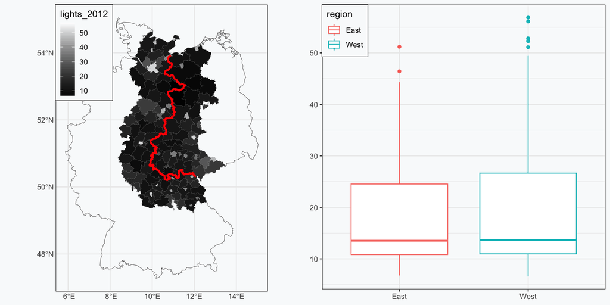

```r
library(gridExtra)

pic1<-ggplot() +
  geom_sf(data=ger0, fill=NA)+
  geom_sf(data=ger_100km, aes(fill=lights_2012), color="white", linewidth=0.01)+
  scale_fill_gradientn(colours=c("black","white"))+
  geom_sf(data = line1, color = "red", linewidth = 1) +
  theme_bw()+
  theme(axis.title = element_blank(),   # Remove axis titles
        axis.ticks = element_blank(),
        legend.box.background = element_rect(fill = "white",
                                             linewidth=0.5, linetype="solid",
                                             colour = "black"),
        legend.position = c(0, 1),
        legend.justification = c(0, 1))


pic2<-ggplot(ger_100km, aes(x = region,
                         y = lights_2012,
                         color=region)) +
  geom_boxplot()+
  theme_bw()+
    theme(axis.title = element_blank(),   # Remove axis titles
        legend.box.background = element_rect(fill = "white",
                                             linewidth=0.5, linetype="solid",
                                             colour = "black"),
        legend.position = c(0, 1),
        legend.justification = c(0, 1))

grid.arrange(pic1, pic2, ncol=2)
```

## Comparison 2012

But are these differences statistically significant?

```r
ger2d_east<-subset(ger_100km, region=="East")
ger2d_west<-subset(ger_100km, region=="West")

test_twosided<-t.test(ger2d_east$lights_2012, ger2d_west$lights_2012,
        alternative = c("two.sided"))
test_twosided
```

```
    Welch Two Sample t-test

data:  ger2d_east$lights_2012 and ger2d_west$lights_2012
t = -1.0548, df = 116.9, p-value = 0.2937
alternative hypothesis: true difference in means is not equal to 0
95 percent confidence interval:
 -6.885571  2.099942
sample estimates:
mean of x mean of y
 18.77206  21.16487
```

In this case, we do not reject the null hypothesis (H0) because p ≥ 0.05 and conclude that there is no significant difference between the means of the two groups.

## Comparison Difference

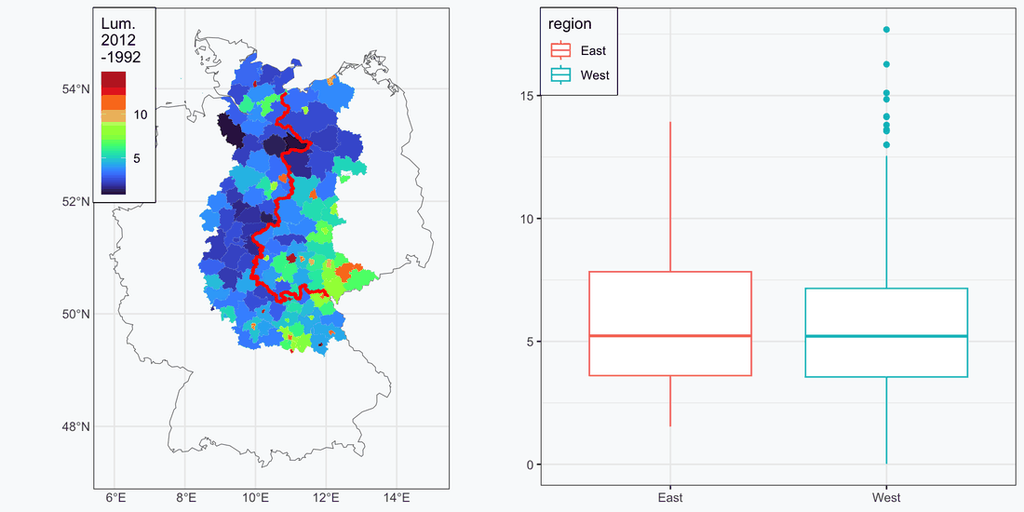

```r
library(viridis)


x3<-ggplot() +
  geom_sf(data=ger0, fill=NA)+
  geom_sf(data=ger_100km, aes(fill=diff), color="white", linewidth=0.01)+
  scale_fill_viridis(option="turbo",
                      name = "Lum. \n2012\n-1992")+
  geom_sf(data = line1, color = "red", linewidth = 1) +
  theme_bw()+
  theme(axis.title = element_blank(),   # Remove axis titles
        axis.ticks = element_blank(),
        legend.box.background = element_rect(fill = "white",
                                             linewidth=0.5, linetype="solid",
                                             colour = "black"),
        legend.position = c(0, 1),
        legend.justification = c(0, 1))



pic2<-ggplot(ger2d, aes(x = region,
                         y = diff,
                         color=region)) +
  geom_boxplot()+
  theme_bw()+
    theme(axis.title = element_blank(),   # Remove axis titles
        legend.box.background = element_rect(fill = "white",
                                             linewidth=0.5, linetype="solid",
                                             colour = "black"),
        legend.position = c(0, 1),
        legend.justification = c(0, 1))

grid.arrange(x3, pic2, ncol=2)
```

## Difference

Is the difference (2012-1992) statistically significant?

```r
ger2d_east<-subset(ger_100km, region=="East")
ger2d_west<-subset(ger_100km, region=="West")

test_twosided<-t.test(ger2d_east$diff, ger2d_west$diff,
        alternative = c("two.sided"))
test_twosided
```

```
    Welch Two Sample t-test

data:  ger2d_east$diff and ger2d_west$diff
t = 2.1327, df = 106.85, p-value = 0.03524
alternative hypothesis: true difference in means is not equal to 0
95 percent confidence interval:
 0.08236554 2.25499225
sample estimates:
mean of x mean of y
 5.994894  4.826215
```

In this case, we reject the null hypothesis (H0) because p < 0.05 and conclude that there is a significant difference between the means of the two groups.

## Observations about the Difference

- When using the entire sample, there was a difference in luminosity in 1992 between the East and the West
- When using the 100-km sample, there was no difference in luminosity in 1992 between the East and the West
- When using the entire sample, there was a difference in luminosity in 2012 between the East and the West
- When using the 100-km sample, there was no difference in luminosity in 2012 between the East and the West
- When using the entire sample, there was no difference in change (2012-1992) between the East and the West
- When using the 100-km sample, there was a difference in change (2012-1992) between the East and the West

## What Have We Learned?

We covered ways to work with rasters.

- cropping raster to a polygon
- zonal statistics: mean
- converting rasters (stars) to polygons
- subtracting rasters

We also reviewed/learned new ways to work with vectors

- Dissolving polygons
- Creating buffers to eliminate internal geometry errors
- Turning polylines into lines
- Calculate centroid distance to a line